# Ej10 sol

## Ejercicio 10

## A

Las fórmulas de cuadratura son de la forma:

$$ \int_{a}^{b}f(x)\,dx\approx \omega_{0}\,f(x_{0})+\omega_{1}\,f(x_{1})+\cdots +\omega_{n}\,f(x_{n}) $$

En particular, la fórmula de Gauss-Legendre con tres nodos es

$$ \int_{-1}^{1}f(x)\: dx\approx\frac{5}{9}\, f\left(-\sqrt{\dfrac{3}{5}}\right)+\frac{8}{9}\, f\left(0\right)+\frac{5}{9}\, f\left(\sqrt{\dfrac{3}{5}}\right) $$

Estos resultados se pueden generalizar a cualquier intervalo $[a,b]$ cambiando los $x_i$ por $y_i$ de acuerdo con la fórmula

$$y_i=\frac{b-a}{2}x_i+\frac{a+b}{2} \quad \quad (1)$$

Y entonces la fórmula de cuadratura es

$$ \int_{a}^{b}f(x)\,dx\approx\frac{b-a}{2}\left( \omega_{0}\;f(y_{0})+\omega_{1}\;f(y_{1}) +\omega_{2}\;f(y_{2})\right) \quad \quad (2) $$

Escribir la función **`gauss(f,a,b)`** que tiene como argumentos de entrada la función **`f`** a integrar y los extremos del intervalo de integración **`a`** y **`b`** y devuelve el valor aproximado utilizando la fórmula gaussiana con $3$ nodos, la integral

$$ \int_0^3 e^x \,dx$$

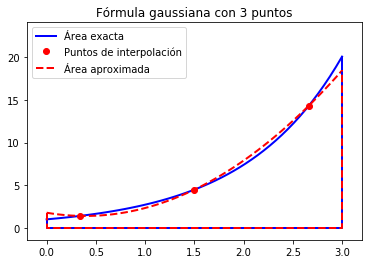

```
El valor aproximado es 19.080330
El valor exacto es     19.085537
```

```python
%matplotlib inline
%run Gaussiana.py
```

Probar también con los datos

```python
f = lambda x: np.log(x)
a = 1.; b = 3;
```

```python
import numpy as np
```

```python
def gauss(f,a,b):
    w=np.array([5./9., 8./9., 5./9.])
    x=np.array([-(3./5.)**0.5, 0., (3./5.)**0.5])
    y = (b-a)/2*x+(b+a)/2
    I = sum(w*f(y))*(b-a)/2
    return I
```

```python
f = lambda x: np.exp(x)
a = 0.; b = 3.;
I = gauss(f,a,b)
print ('El valor aproximado para exp(x) es %f' % (I))
```

```
El valor aproximado para exp(x) es 19.080330
```

```python
f = lambda x: np.log(x)
a = 1.; b = 3.;
I = gauss(f,a,b)
print ('El valor aproximado para log(x) es %f' % (I))
```

```
El valor aproximado para log(x) es 1.296006
```

## B

Una forma de disminuir el error de la fórmula anterior es aumentar el número de nodos utilizando las fórmulas compuestas. Estas se obtienen dividiendo el intervalo $\left[ a,b\right] $ en $n$ subintervalos y aplicando a cada uno de estos subintervalos una fórmula de cuadratura sencilla.

Podemos dividir el intervalo $\left[ a,b\right]$ en $n$ subintervalos de igual longitud usando los puntos $p_{0},p_{1},...,p_{n}$ como extremos de los subintervalos y aplicar en cada uno de los subintervalos $[p_{k-1},p_{k}]$ la fórmula simple.

Escribir la función **`gauss_com(f,a,b,n)`** que tiene como argumentos de entrada la función **`f`** a integrar, los extremos del intervalo de integración **`a`** y **`b`** y el número de subintervalos **`n`** y devuelve el valor aproximado utilizando la fórmula gaussiana con $3$ nodos compuesta.

Usarla para calcular la integral siguiente, usando $n = 4$ subintervalos

$$ \int_0^3 e^x \,dx$$

Probar también con los datos

```python
f = lambda x: np.log(x)
a = 1.; b = 3.; n = 10
```

```python
def gauss_comp(f,a,b,n):
    p = np.linspace(a,b,n+1)
    I = 0.
    for i in range(n):
        s = gauss(f,p[i],p[i+1])
        I += s
    return I
```

```python
f = lambda x: np.exp(x)
a = 0.; b = 3; n = 4;
I = gauss_comp(f,a,b,n)
print ('El valor aproximado para exp(x) es %f' % (I))
```

```
El valor aproximado para exp(x) es 19.085535
```

```python
f = lambda x: np.log(x)
a = 1.; b = 3.; n = 10;
I = gauss_comp(f,a,b,n)
print ('El valor aproximado para log(x) es %f' % (I))
```

```
El valor aproximado para log(x) es 1.295837
```